# Homework 6 — Three ways to estimate latency risk

STA5001 Bayesian & Computational Statistics

The starter code uses the BayesComp package from this checkout. To install it, run `R CMD INSTALL BayesComp` from the repository root.

**Concept.** Inversion, rejection, and self-normalized importance sampling can target the same posterior quantity. Their error estimates depend on how draws or weights contribute to that quantity.

**Example.** Each synthetic batch compares average latency with and without a check on the same requests. Let $Y_i$ be the paired difference in milliseconds. Treat the 12 batches as independent and model $Y_i\mid\theta\sim N(\theta,180^2)$. The noise variance is known. Use a $N(0,150^2)$ prior conditioned on $\theta\geq0$. Estimate $\Pr(\theta>100\mid\mathbf y)$, where $\theta$ is the mean added latency under the stated configuration.

**Starter code.** Load the paired differences and display them by batch. The observed differences can be negative because of timing noise.

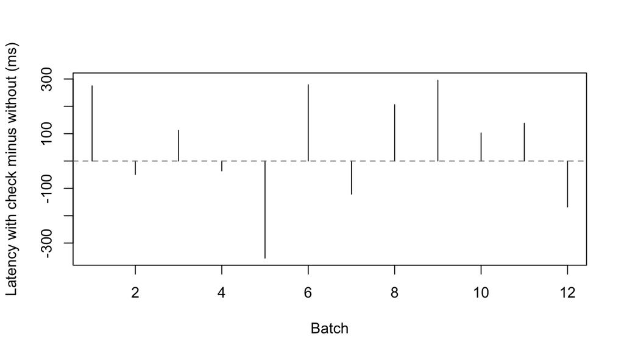

Paired differences in batch-average latency.

```r
data("hw06_latency", package = "BayesComp")
plot(difference_ms ~ batch, data = hw06_latency, type = "h",
     xlab = "Batch", ylab = "Latency with check minus without (ms)")
abline(h = 0, lty = 2, col = "grey45")
```

## Tasks

1. **Construct a reference and invert the CDF.** Use the conjugate Gaussian update on the real line, then condition on the nonnegative half-line. Write the resulting CDF and inverse. Compute the reference tail probability and estimate it by inverting 20,000 independent uniforms. Report the iid MCSE.
2. **Use the prior as a rejection proposal.** Establish a global likelihood bound on $\theta\geq0$ by locating the constrained likelihood maximum. Generate 20,000 proposal values using the half-Normal prior, and apply the accept/reject rule on the log scale. Report the acceptance fraction and estimate the tail probability with an iid MCSE based on the retained draws.
3. **Reweight the same proposals.** Compute self-normalized importance weights for the proposals in Task 2. Report the estimated tail probability, the functional-specific SNIS MCSE from Section 6.3, and the weight ESS. Explain which draws contribute to the rejection estimate and which contribute to the weighted estimate.

**Outputs and visuals.** State the seed and report the reference and three simulated estimates with their MCSEs. Plot the estimates with two-MCSE error bars and a horizontal line for the reference. Explain how the precision compares at the stated draw budget. For rejection, include the number retained so the comparison accounts for work.

**Public-data reference.** The `sleep` data offer a public example of a paired design in which both treatments are measured on each subject. [R documentation for sleep](https://stat.ethz.ch/R-manual/R-devel/library/datasets/html/sleep.html)

R 4.6.0 · BayesComp 0.1.0